# distribution-fitting-nb

Forecast Modeling · Portfolio Notebook

Distribution Fitting and Correlated Revenue Forecasting for a Multi-Site Operation

This notebook fits empirical demand distributions using chi-square goodness-of-fit, then compares independent vs. correlated Monte Carlo simulations to quantify how ignoring cross-site correlation understates aggregate risk.

**Author:** Oscar D. Nava Quintero · [caelusbellum.github.io](https://caelusbellum.github.io/)  
**Course:** AD616 — Enterprise Risk Analytics, Boston University Metropolitan College  
**Program:** MS in Applied Business Analytics  
**Source:** AD616 Assignment 3 · original coursework; datasets and problem statements are anonymized or synthetic  
**Language / stack:** Python (NumPy, SciPy, pandas, Matplotlib), Jupyter

Shared as a portfolio artifact. Not intended for reuse as academic submission. © Oscar D. Nava Quintero.

# AD616 Assignment 3

**Oscar Quintero**  
ERA616 – Simulation & Risk Analysis  
Date: May 2026

## Question 1

GWS is a company that markets outboard motorboats directly to consumers for recreational use. Recently, they’ve been developing a project they think has a lot of potential: the first mass market boats with electric motors. They haven’t started advertising their new product yet, nor have they organized a presale because they don’t want to lose their first-mover advantage. As a result, GWS has a limited understanding of the size of the market for their new project. They plan to retail their boats for $150,000, but after two years, when competition enters the market and the novelty factor wears off, they’ll have to drop the price to $70,000, and they will be eventually sold at $70,000. They hire a consultant who estimates that at this price point, over the next two years, demand for the new boats will be somewhere between 2,000 and 15,000, with probabilities as in the **Table 1** below:

| Demand | Probability |
| --- | --- |
| 2,000-5,000 | 35% |
| 5,001-10,000 | 40% |
| 10,001-14,000 | 20% |
| 14,001-15,000 | 5% |

**Table 1: Discrete Distribution of Demand for GWS Electric Boats**

The fixed cost of manufacturing any number of boats is normally distributed, with a mean of $300 million and a standard deviation of $60 million. They estimate that the variable cost to produce one boat will be a minimum of $77 thousand and a maximum of $100 thousand, with a most likely value of $90,000. Develop four Monte Carlo Simulations to calculate their total profit over the two year period assuming they produce a. 4,000 boats b. 8,000 boats c. 12,000 boats d. 15,000 boats For each simulation, provide the mean and standard deviation as well as a histogram.

### Problem Statement

GWS is launching electric motorboats

- First 2 years: $150,000 per boat
- After 2 years: $70,000 per boat (due to competition)

**Uncertain Variables:**

- Demand over 2 Years looks like discrete distribution (competitive advantage)
- Fixed Cost ~ Normal Distribution
  - $\mu$ = $300M,
  - $\sigma$ = $60M
- Variable Cost ~ Triangular Distribution
  - min = $77k
  - mode = $90k
  - max = $100k

**Monte Carlo Simulations:** Run 10,000 simulations at 4,000, 8,000, 12,000, and 15,000 boats to estimate total profit, and analyze results (mean, std dev, histogram).

**What is the expected profit for each production level, and what is the best production, if any, based on the simulations?**

#### Generating Demand (Discrete Distribtion)

The consultant's estimates for demand can be represented as a discrete distribution. Try using the probabilities according to **Table 1** to generate random demand values for each simulation.

#### Generating the Costs

**Fixed Cost** (one-time manufacturing setup cost):
$$ \text{FixedCost}_i \sim \text{Normal}(\mu = 300,000,000,\ \sigma = 60,000,000) $$

**Variable Cost per boat**:
$$ \text{VarCost}_i \sim \text{Triangular}(a = 77,000,\ c = 90,000,\ b = 100,000) $$

where:

- $a$ = minimum value ($77,000)
- $c$ = mode (most likely value = $90,000)
- $b$ = maximum value ($100,000)
- $i$ = simulation trial number

The **total** variable cost for producing $Q$ boats in simulation $i$ looks like: $$ \text{TotalVarCost}_i = Q \times \text{VarCost}_i $$

#### Calculating Profit, Sales, and Revenue

For the production of $Q$ boats with demand $D_i$ in simulation $i$, calculate revenue for the first 2 years; then additional produced after the first 2 years that are sold at the lower price.

Total Revenue: $$ \text{TotalRevenue}_i = \text{RevenueFirst2YearsHigh}_i + \text{RevenueAfter2YearsLow}_i $$

#### Profit per Simulation:

For each simulation $i$, calculate profit as: $$ \text{Profit}_i = \text{TotalRevenue}_i - \text{FixedCost}_i - \text{TotalVarCost}_i $$ Run 10,000 simulations for each production level (4,000, 8,000, 12,000, and 15,000 boats) to estimate total profit, and analyze results (mean, std dev, histogram).

#### Analyzing Results for Decision-Making Recommendations

We are looking for the expected profit for each production level as well as the best production level based on the simulations. This will drive the decision on how many boats to produce, or not produce according to the consultant's estimates of demand and probability (**Table 1**).

```python
import numpy as np
import pandas as pd
import matplotlib.pyplot as plt
import seaborn as sns

np.random.seed(42)  # For reproducibility
n_trials = 10_000

# Demand distribution
demand_ranges = [(2000, 5000), (5001, 10_000), (10_001, 14_000), (14_001, 15_000)]
demand_probabilities = [0.35, 0.40, 0.20, 0.05]

def simulate_profit(quantity):
    profits = np.zeros(n_trials)

    for i in range(n_trials):
        # Generate demand
        demand_bin = np.random.choice(4, p=demand_probabilities)
        low, high = demand_ranges[demand_bin]
        demand = np.random.randint(low, high + 1)

        # Generate the Costs
        fixed_cost = np.random.normal(300_000_000, 60_000_000)
        variable_cost = np.random.triangular(77_000, 90_000, 100_000, n_trials)[i]

        # Calculate Sales and Revenue
        sold_at_high_price = min(quantity, demand)  # First 2 years at $150k
        sold_at_low_price = max(0, quantity - demand)  #fixed.  Originally was demand - quantity, which could be negative if demand < quantity.

        revenue = sold_at_high_price * 150_000 + sold_at_low_price * 70_000
        total_variable_cost = quantity * variable_cost

        profit = revenue - fixed_cost - total_variable_cost
        profits[i] = profit

    return profits

# Run the simulations for all quantities
quantities = [4000, 8000, 12000, 15000]
results = {}

for q in quantities:
    results[q] = simulate_profit(q)
    print(f"Completed simulation for {q:,} boats")
```

```
Completed simulation for 4,000 boats
Completed simulation for 8,000 boats
Completed simulation for 12,000 boats
Completed simulation for 15,000 boats
```

```python
# Summary Table
summary = []
for q in quantities:
    p = results[q]
    summary.append({
        'Quantity': q,
        'Mean Profit': np.mean(p),
        'Std Dev': np.std(p),
        'Prob Loss': (p < 0).mean(),
        'Min Profit': p.min(),
        'Max Profit': p.max(),
        # '5th Percentile': np.percentile(p, 5),
        # '95th Percentile': np.percentile(p, 95)
    })

df_summary = pd.DataFrame(summary)
print(df_summary.round(2))
```

```
   Quantity  Mean Profit       Std Dev  Prob Loss    Min Profit    Max Profit
0      4000 -74181922.20  7.518646e+07       0.85 -4.038655e+08  1.764881e+08
1      8000  33166706.55  1.805792e+08       0.40 -4.916630e+08  4.199820e+08
2     12000  40422714.42  2.736257e+08       0.48 -5.850179e+08  6.790424e+08
3     15000   7008342.13  3.085521e+08       0.53 -6.346000e+08  8.598502e+08
```

#### Histograms of Profit for Each Production Level

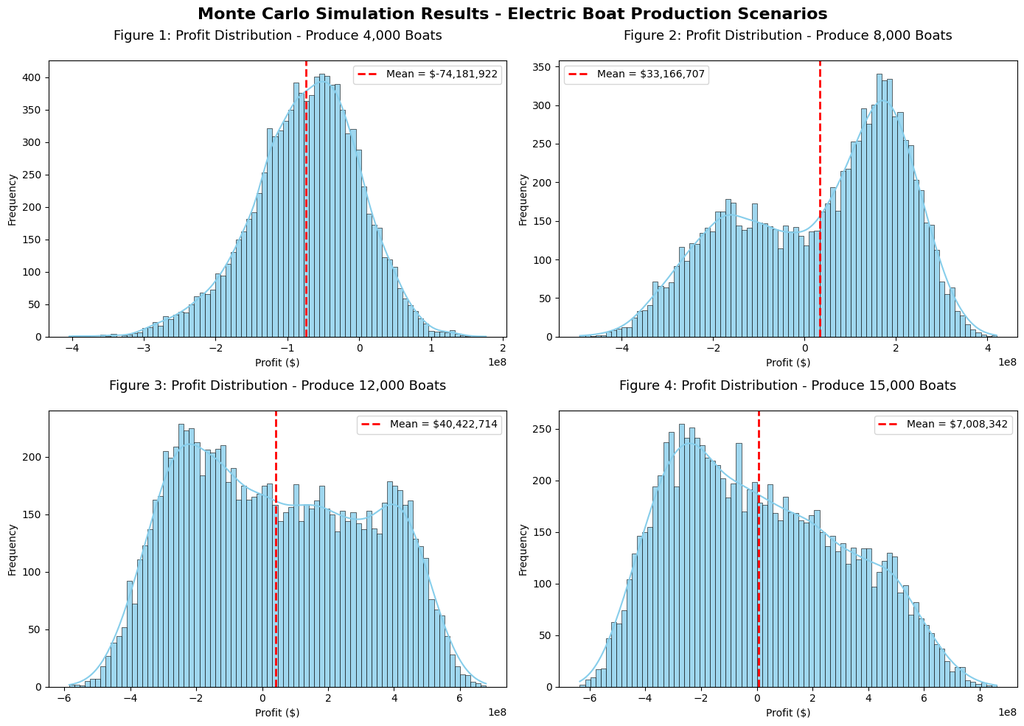

```python
# ====================== PROFIT HISTOGRAMS WITH FIGURE LABELS ======================
fig, axes = plt.subplots(2, 2, figsize=(14, 10))
axes = axes.ravel()

quantities = [4000, 8000, 12000, 15000]

for i, q in enumerate(quantities):
    profits = results[q]
    mean_profit = profits.mean()

    # Plot histogram
    sns.histplot(profits, bins=80, kde=True, color='skyblue',
                 edgecolor='black', alpha=0.8, ax=axes[i])

    # Add Figure label at the top of each subplot
    axes[i].set_title(f'Figure {i+1}: Profit Distribution - Produce {q:,} Boats',
                      fontsize=13, pad=20)

    axes[i].set_xlabel('Profit ($)')
    axes[i].set_ylabel('Frequency')
    axes[i].axvline(mean_profit, color='red', linestyle='--', linewidth=2,
                    label=f'Mean = ${mean_profit:,.0f}')
    axes[i].legend()

plt.suptitle('Monte Carlo Simulation Results - Electric Boat Production Scenarios',
             fontsize=16, fontweight='bold', y=0.98)
plt.tight_layout()
plt.savefig('Boat_Production_Profit_Histograms.png', dpi=300, bbox_inches='tight')
plt.show()
```

#### Conclusion:

Selling 8,000 boats is the recommmended course of action for GWS because the chance of profitability is higher than the other options, and the risk of losing profit is lower. As a data analyst, I would recommend that GWS produce 8,000 boats based on the simulations and analysis of the results. If decision-makers chose another option based on their risk tolerance, the next best option is producing 12,000 boats because it has a higher mean profit, and risk is lower than producing 15,000 boats. Producing 4,000 boats is the least attractive option because it has the lowest mean profit and the highest risk of losing profit.

## Question 2

The Baker’s Inn is a small chain of restaurants in the New England area, that, in addition to accepting reservations, allow patrons to reserve an event space for private functions. Until now, the chain has limited reservations for its event spaces to parties of ten or more. The proprietor of the chain is considering expanding the spaces or possibly ceasing to offer private functions, but wishes to model the revenue they can generate. The chain collects data on the previous 100 private functions, including the number of people in each party and the amount each party spent per person (see .csv file). a. Create a histogram of the party sizes. Which distribution do you think would best fit the data? Choose from among discrete uniform, geometric, and Poisson. b. In order to best fit the data, we need to shift the distribution to the left by subtracting a positive integer from the value of party size. What number should we subtract to get the best fit? What are the parameter(s) of the best fit distribution? c. We now need to fit a distribution to the per person spending. Which of the following distributions results in the best fit, according to the KS statistic: Cauchy, gamma, logistic, lognormal, normal, or Weibull? What are the parameter(s)? d. Create a QQ plot and a density comparison plot for the distribution you chose from part (c). Does the distribution appear to be a good fit? e. Does it appear that party size and per person spending are correlated? f. Using the distributions and parameters from parts (a)-(c) and the correlation from part e, construct an MC simulation with 100,000 trials to create a risk profile for the revenue generated from a single event. Create a histogram and provide the mean and standard deviation. (Hint: don’t forget to shift the distribution of party size back to the right.) g. According to your simulation, how often will a private function generate at least $5000? h. Repeat parts (f) and (g), but build a simulation that ignores the correlation. How does this affect your results?

### Baker's Inn Simulation

The Baker's Inn wants to know if it is better to add more space for private events or to stop offering private events.

We need to:

- Analyze the distribution of party sizes and per person spending
- Assess correlation between the two variables
- Build a Monte Carlo Simulation of 100,000 trials to develop a risk profile for revenue per event
- Compare the correlated vs. independent simulations.

There are two variables in the data set with 100 observations each:

- Party Size (number of people in each party) (**discrete** variable)
- Per Person Spending (amount spent per person in each party) (**continuous** variable)

By calculating the summary statistics, for each variable, we can better understand the distribution of the data. Below is a Python code that calculates the summary statistics for both variables.

```python
import numpy as np
import pandas as pd
import matplotlib.pyplot as plt
import seaborn as sns
from scipy import stats
import warnings
warnings.filterwarnings('ignore')

# Load the Data
df = pd.read_csv('Assignment_3_Problem_2_data.csv')

print("Dataset Shape:", df.shape)
print("Column Names:", df.columns.tolist())
display(df.head())

# Basic Statistics
print("\n=== Summary Statistics ===")
print(df.describe())
```

```
Dataset Shape: (100, 2)
Column Names: ['party_size', 'rev_per_person']
```

|  | party_size | rev_per_person |
| --- | --- | --- |
| 0 | 17 | 151.79 |
| 1 | 23 | 159.09 |
| 2 | 22 | 213.09 |
| 3 | 22 | 150.50 |
| 4 | 15 | 132.59 |

```
=== Summary Statistics ===
       party_size  rev_per_person
count  100.000000      100.000000
mean    19.840000      173.547700
std      3.158186       43.921403
min     13.000000       81.420000
25%     17.750000      143.637500
50%     20.000000      168.860000
75%     22.000000      198.612500
max     27.000000      293.590000
```

#### Part (a): Histogram of Party Sizes and Distribution Fit

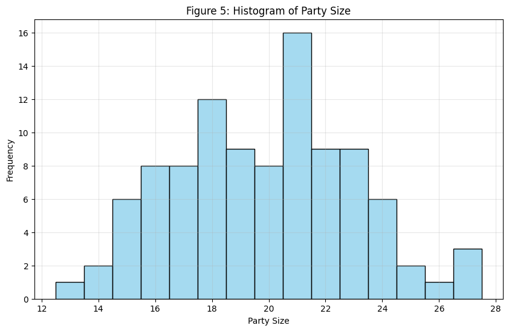

```python
party_size = df['party_size']

# Histogram of Party Size
plt.figure(figsize=(10, 6))
sns.histplot(party_size, bins=15, discrete=True, color='skyblue', edgecolor='black')
plt.title('Figure 5: Histogram of Party Size')
plt.xlabel('Party Size')
plt.ylabel('Frequency')
plt.grid(True, alpha=0.3)
plt.show()
```

#### Part (b): Chi-squared Test for Goodness of Fit / Shifting the Distribution

For discrete distributions, we need to use Chi-squared goodness of fit testing to determine which distribution best fits the data.
The Chi-squared test compares the observed frequencies of party sizes to the expected frequencies under each distribution. The test statistic is calculated as: $$ \chi^2 = \sum_{i=1}^{k} \frac{(O_i - E_i)^2}{E_i} $$ where $O_i$ is the observed frequency for category $i$, $E_i$ is the expected frequency for category $i$, and $k$ is the number of categories.

Below is a Python code that performs the Chi-squared goodness of fit test to determine which distribution best fits the party size data.

```python
from scipy.stats import chisquare

min_size = party_size.min()
shift = min_size - 1  # Shift to start at 1

print(f"Minimum party size: {min_size}")
print(f"Shift applied     : {shift}\n")

# Prepare observed frequencies
observed_freq = party_size.value_counts().sort_index()

x = observed.index.values

# Prepare bins for testing the expected frequencies
# bins = np.arange(party_size.min(), party_size.max() + 2) # +2 to include the last value in the bins

# === Shifted Poisson Distribution ===
# Estimate lambda (mean) for the shifted Poisson
poisson_lambda = party_size.mean() - shift
expected_poisson = stats.poisson.pmf(bins[:-1] - shift, mu=poisson_lambda) * len(party_size)

# === Shifted Geometric Distribution ===
geom_p = 1 / (party_size.mean() - shift + 1)  # p = 1/(mean + 1) for shifted geometric
expected_geom = stats.geom.pmf(bins[:-1] - shift, p=geom_p) * len(party_size)

# Chi-squared tests
print("=== Goodness of Fit Test ===")

chi2_p, p_poisson = stats.chisquare(observed_freq, expected_poisson * (observed.sum() / expected_poisson.sum()))
chi2_geom, p_geom = stats.chisquare(observed_freq, expected_geom * (observed.sum() / expected_geom.sum()))

print(f"Shifted Poisson (lambda={poisson_lambda:.2f}): Chi-squared = {chi2_p:.3f}, p-value = {p_poisson:.4f}")
print(f"Shifted Geometric (p={geom_p:.4f}): Chi-squared = {chi2_geom:.3f}, p-value = {p_geom:.4f}")
```

[output not shown]

#### Results of Best Fit for Party Size

A smaller $chi^2$ statistic means the observed values are close to the expected values, which indicates a better fit of the distribution to the data.

A higher p-value also means the observed values are close to the expected values, which indicates a better fit of the distribution to the data.

After performing a Chi-squared goodness of fit test by shifting the data, the **Poisson** model seems to be the best fit for the party size data.

- **Shifted Poisson**: $\lambda$ = 7.84, $\chi^2$ = 18.935, p-value = 0.1674
- **Shifted Geometric**: $p$ = 0.1131, $\chi^2$ = 62.726, p-value = 0.0000

#### Part (c): Distribution Fit for Revenue Per Person Spending

To determine which distribution best fits the revenue per person spending data, we can use the Kolmogorov-Smirnov (KS) test. The KS test compares the empirical distribution of the data to a specified theoretical distribution and calculates a statistic that measures the distance between the two distributions. The distribution with the smallest KS statistic is considered the best fit for the data. Below is a Python code that performs the KS test for the specified distributions.

```
=== Revenue Per Person Summary ===
count    100.000000
mean     173.547700
std       43.921403
min       81.420000
25%      143.637500
50%      168.860000
75%      198.612500
max      293.590000
Name: rev_per_person, dtype: float64
```

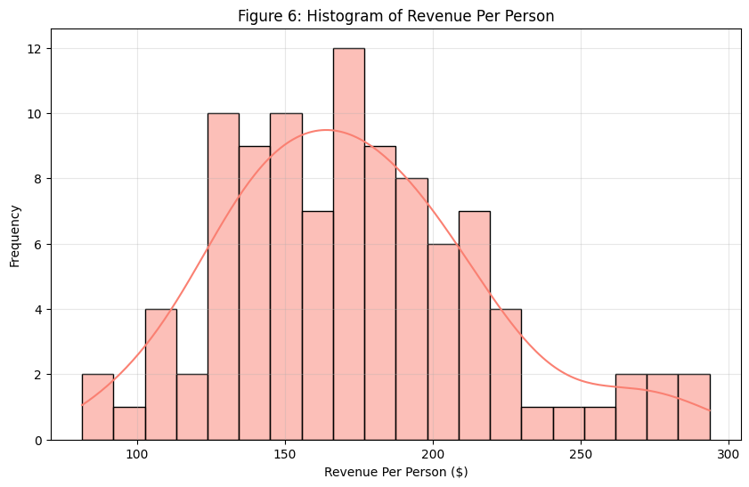

```
=== Distribution Fit Ranking (Lower KS = Better Fit) ===
```

|  | Distribution | KS Statistic | p-value | Parameters |
| --- | --- | --- | --- | --- |
| 0 | lognorm | 0.0347 | 0.9994 | [0.1947, -49.1555, 218.5245] |
| 1 | gamma | 0.0362 | 0.9989 | [12.5432, 18.7471, 12.3414] |
| 2 | logistic | 0.0399 | 0.9954 | [171.1007, 24.5527] |
| 3 | weibull_min | 0.0470 | 0.9724 | [2.4348, 73.0116, 113.2939] |
| 4 | norm | 0.0621 | 0.8118 | [173.5477, 43.7012] |
| 5 | cauchy | 0.0926 | 0.3366 | [167.8257, 25.3585] |

```python
revenue_per_person = df['rev_per_person']

print("=== Revenue Per Person Summary ===")
print(revenue_per_person.describe())

# Histogram
plt.figure(figsize=(10, 6))
sns.histplot(revenue_per_person, bins=20, kde=True, color='salmon', edgecolor='black')
plt.title('Figure 6: Histogram of Revenue Per Person')
plt.xlabel('Revenue Per Person ($)')
plt.ylabel('Frequency')
plt.grid(True, alpha=0.3)
plt.show()

# Candidate Distributions with correct scipy names
distributions = {
    'norm': stats.norm,
    'lognorm': stats.lognorm,
    'gamma': stats.gamma,
    'logistic': stats.logistic,
    'weibull_min': stats.weibull_min,
    'cauchy': stats.cauchy
}

results = []

for name, dist in distributions.items():
    # Fit parameters
    params = dist.fit(revenue_per_person)

    # KS Test
    ks_stat, p_value = stats.kstest(revenue_per_person, name, args=params)

    results.append({
        'Distribution': name,
        'KS Statistic': ks_stat,
        'p-value': p_value,
        'Parameters': [round(p, 4) for p in params]
    })

# Display ranked by best fit (lowest KS statistic)
fit_df = pd.DataFrame(results)
fit_df = fit_df.sort_values('KS Statistic').reset_index(drop=True)

print("\n=== Distribution Fit Ranking (Lower KS = Better Fit) ===")
display(fit_df.round(4))
```

#### Results of Best Fit for Revenue Per Person

In tke KS test, a smaller KS statistic means the distribution is a better fit for the data. A higher p-value also means the distribution is a better fit for the data. After performing the KS test, the **lognormal** distribution seems to be the best fit for the revenue per person.

#### Part (d): QQ Plot and Density Comparison Plot for Revenue Per Person

A Q-Q plot is a scatter plot that compares the quantiles of the fitted distribution to the actual observations in the data.

Below is a Python code that creates a Q-Q plot and a density comparison for the lognormal distribution to see how well it fits the revenue per person data.

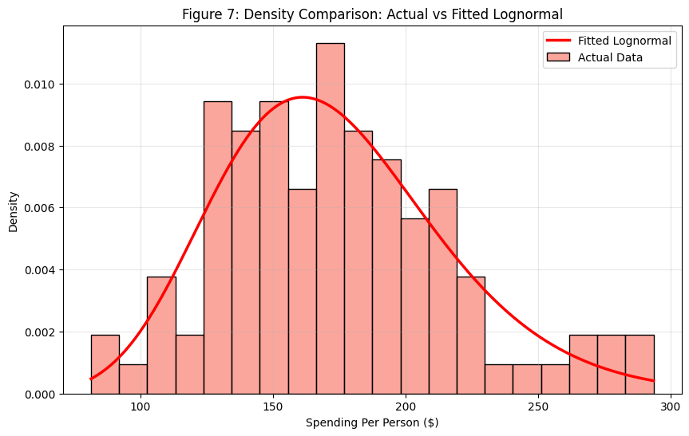

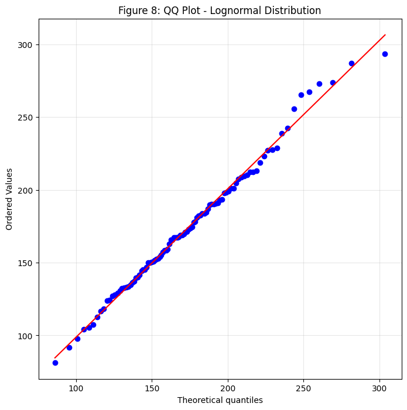

```python
spending = df['rev_per_person']
params = stats.lognorm.fit(spending)   # Best fit parameters

# Density Comparison Plot
plt.figure(figsize=(10, 6))
sns.histplot(spending, bins=20, kde=False, color='salmon',
             edgecolor='black', alpha=0.7, stat="density", label="Actual Data")

x = np.linspace(spending.min(), spending.max(), 500)
plt.plot(x, stats.lognorm.pdf(x, *params), 'r-', linewidth=2.5,
         label='Fitted Lognormal')

plt.title('Figure 7: Density Comparison: Actual vs Fitted Lognormal')
plt.xlabel('Spending Per Person ($)')
plt.ylabel('Density')
plt.legend()
plt.grid(True, alpha=0.3)
plt.show()

# QQ Plot
plt.figure(figsize=(8, 8))
stats.probplot(spending, dist="lognorm", sparams=params, plot=plt)
plt.title('Figure 8: QQ Plot - Lognormal Distribution')
plt.grid(True, alpha=0.3)
plt.show()
```

**Results** Both the density comparison plot (**Figure 7**) and the QQ plot (**Figure 8**) show that the **Lognormal distribution** fits the per-person spending data very well. The points in the QQ plot closely follow the straight line, indicating good agreement between the empirical data and the theoretical distribution.

#### Part (e): Correlation Analysis

Since one variable is discrete and the other is continuous, the Spearman correlation may be the best option to assess the correlation between party size and per person spending. Scipy stats.spearmanr can be used to calculate the Spearman correlation coefficient and the p-value to determine if there is a statistically significant correlation between the two variables. Below is a Python code that performs the Pearson and Spearman correlation analysis.

```
=== Correlation Analysis ===
Pearson Correlation  : 0.5068 (p-value = 0.0000)
Spearman Correlation : 0.5088 (p-value = 0.0000)
```

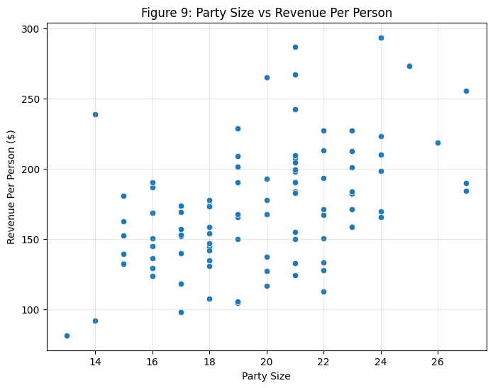

```python
# Correlation Analysis
pearson_corr, pearson_p = stats.pearsonr(df['party_size'], df['rev_per_person'])
spearman_corr, spearman_p = stats.spearmanr(df['party_size'], df['rev_per_person'])

print("=== Correlation Analysis ===")
print(f"Pearson Correlation  : {pearson_corr:.4f} (p-value = {pearson_p:.4f})")
print(f"Spearman Correlation : {spearman_corr:.4f} (p-value = {spearman_p:.4f})")

# Scatter Plot
plt.figure(figsize=(8, 6))
sns.scatterplot(x='party_size', y='rev_per_person', data=df)
plt.title('Figure 9: Party Size vs Revenue Per Person')
plt.xlabel('Party Size')
plt.ylabel('Revenue Per Person ($)')
plt.grid(True, alpha=0.3)
plt.show()
```

#### Results of the Correlation Analysis

The Spearman correlation coefficient is 0.5088, which indicates a moderate positive correlation between party size and per person spending. The p-value is 0.0000, which means the correlation is statistically significant at the 5% significance level. **Figure 9** shows the scatter plot of party size versus revenue per person, which visually supports the positive correlation. This means that there is a significant positive correlation between party size and per person spending; as the party size increases, the per person spending also tends to increase.

#### Part (f): Monte Carlo Simulation for Revenue Per Event

Using the distributions and parameters from parts (a)-(c) and the correlation from part e, we can construct a Monte Carlo simulation with 100,000 trials to create a risk profile for the revenue generated from a single event. Below is a Python code that performs this simulation and creates a histogram of the results, along with the mean and standard deviation of the simulated revenues.

```python
import numpy as np
import matplotlib.pyplot as plt
import seaborn as sns
from scipy.stats import poisson, lognorm

np.random.seed(42)
n_trials = 100_000

# Parameters from earlier fitting
shift = 12                                 # From min party size = 13
poisson_lambda = 7.84                      # Shifted Poisson parameter
spending_params = lognorm.fit(df['rev_per_person'])   # Best fit for spending

correlation = 0.5088                       # From Spearman correlation

revenues = np.zeros(n_trials)

for i in range(n_trials):
    # Generate correlated uniforms
    u1 = np.random.rand()
    u2 = stats.norm.cdf(
        stats.norm.ppf(u1) * correlation +
        stats.norm.ppf(np.random.rand()) * np.sqrt(1 - correlation**2)
    )

    # Party Size (Shifted Poisson → shift back to original scale)
    party_size_sim = poisson.ppf(u1, mu=poisson_lambda) + shift   # ← Shift back!

    # Per Person Spending (Lognormal)
    spend_sim = lognorm.ppf(u2, *spending_params)

    # Total Revenue
    revenues[i] = party_size_sim * spend_sim

# ====================== RESULTS ======================
print("=== REVENUE SIMULATION RESULTS (100,000 trials) ===")
print(f"Mean Revenue    : ${revenues.mean():,.2f}")
print(f"Std Dev Revenue : ${revenues.std():,.2f}")
print(f"Min Revenue     : ${revenues.min():,.2f}")
print(f"Max Revenue     : ${revenues.max():,.2f}")
print(f"P(Revenue ≥ $5000): {(revenues >= 5000).mean():.1%}")
```

```
=== REVENUE SIMULATION RESULTS (100,000 trials) ===
Mean Revenue    : $3,505.84
Std Dev Revenue : $1,223.56
Min Revenue     : $616.90
Max Revenue     : $12,615.75
P(Revenue ≥ $5000): 11.3%
```

#### Results and Histogram on MC Simulation

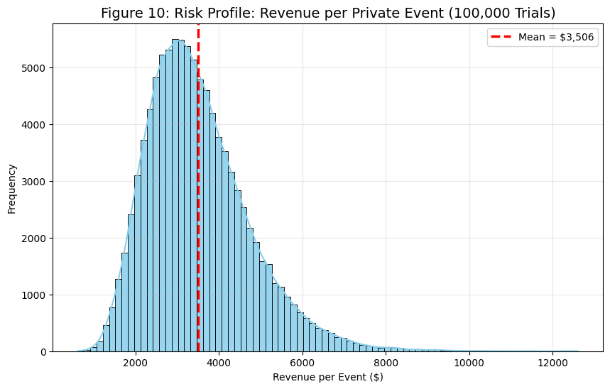

```python
plt.figure(figsize=(10, 6))
sns.histplot(revenues, bins=80, kde=True, color='skyblue', edgecolor='black', alpha=0.85)

plt.title('Figure 10: Risk Profile: Revenue per Private Event (100,000 Trials)', fontsize=14)
plt.xlabel('Revenue per Event ($)')
plt.ylabel('Frequency')
plt.axvline(revenues.mean(), color='red', linestyle='--', linewidth=2.5,
            label=f'Mean = ${revenues.mean():,.0f}')
plt.legend()
plt.grid(True, alpha=0.3)

plt.savefig('Baker_Inn_Revenue_Risk_Profile.png', dpi=300, bbox_inches='tight')
plt.show()
```

#### Part (g)-(h): Probability of Generating at Least $5000 and Comparison of Correlated and Independent Simulations

To calculate the probability of generating at least $5000 from a private event, we can count the number of simulated revenues that are greater than or equal to $5000 and divide by the total number of simulations (100,000). Below is a Python code that performs this calculation for the correlated and independent simulations.

```python
import numpy as np
import matplotlib.pyplot as plt
import seaborn as sns
from scipy.stats import poisson, lognorm

np.random.seed(42)
n_trials = 100_000

# Parameters from fitting
shift = 12
poisson_lambda = 7.84
spending_params = lognorm.fit(df['rev_per_person'])
correlation = 0.5088

# ====================== CORRELATED SIMULATION ======================
revenues_correlated = np.zeros(n_trials)

for i in range(n_trials):
    u1 = np.random.rand()
    u2 = stats.norm.cdf(stats.norm.ppf(u1) * correlation +
                       stats.norm.ppf(np.random.rand()) * np.sqrt(1 - correlation**2))

    party_size_sim = poisson.ppf(u1, mu=poisson_lambda) + shift   # Shift back!
    spend_sim = lognorm.ppf(u2, *spending_params)

    revenues_correlated[i] = party_size_sim * spend_sim

# ====================== INDEPENDENT SIMULATION ======================
revenues_independent = np.zeros(n_trials)

for i in range(n_trials):
    party_size_sim = poisson.ppf(np.random.rand(), mu=poisson_lambda) + shift
    spend_sim = lognorm.ppf(np.random.rand(), *spending_params)
    revenues_independent[i] = party_size_sim * spend_sim

# ====================== RESULTS ======================
print("=== REVENUE SIMULATION RESULTS (100,000 trials) ===")
print(f"Correlated Mean Revenue   : ${revenues_correlated.mean():,.2f}")
print(f"Independent Mean Revenue  : ${revenues_independent.mean():,.2f}")
print(f"Correlated Std Dev        : ${revenues_correlated.std():,.2f}")
print(f"Independent Std Dev       : ${revenues_independent.std():,.2f}")
print(f"\nP(Revenue ≥ $5000 | Correlated)   : {(revenues_correlated >= 5000).mean():.1%}")
print(f"P(Revenue ≥ $5000 | Independent) : {(revenues_independent >= 5000).mean():.1%}")
```

```
=== REVENUE SIMULATION RESULTS (100,000 trials) ===
Correlated Mean Revenue   : $3,505.84
Independent Mean Revenue  : $3,442.81
Correlated Std Dev        : $1,223.56
Independent Std Dev       : $1,002.82

P(Revenue ≥ $5000 | Correlated)   : 11.3%
P(Revenue ≥ $5000 | Independent) : 7.3%
```

#### Results of Correlated vs. Independent Simulations

In this scenario, the difference in mean revenue between the correlated and independent simulations is not significant, but the probability of generating at least $5000 is higher in the correlated simulation (11.3%) compared to the independent simulation (7.3%). This suggests that accounting for the correlation between party size and per person spending can lead to a more accurate estimation of the revenue generated from private events, and it may indicate a higher likelihood of achieving higher revenues when considering the correlation.

**Figure 11** and **Figure 12** show the histograms of the correlated and independent simulations, respectively. While the mean revenue is very similary, the distribution of revenues in the correlated simulation is more skewed to the right, which indicates a higher likelihood of generating higher revenues compared to the independent simulation. This means that by analyzing the correlation, there seems to be a benefit in terms of revenue estimation and risk assessment for private events at the Baker's Inn.

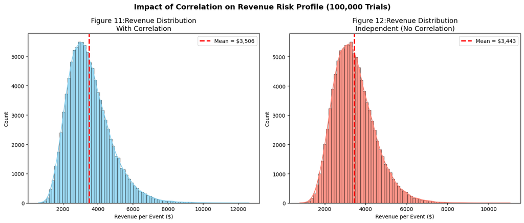

```python
fig, axes = plt.subplots(1, 2, figsize=(14, 6))

# Correlated Simulation
sns.histplot(revenues_correlated, bins=80, kde=True, color='skyblue',
             edgecolor='black', alpha=0.85, ax=axes[0])
axes[0].axvline(revenues_correlated.mean(), color='red', linestyle='--', linewidth=2.5,
                label=f'Mean = ${revenues_correlated.mean():,.0f}')
axes[0].set_title('Figure 11:Revenue Distribution\nWith Correlation', fontsize=13)
axes[0].set_xlabel('Revenue per Event ($)')
axes[0].legend()

# Independent Simulation
sns.histplot(revenues_independent, bins=80, kde=True, color='salmon',
             edgecolor='black', alpha=0.85, ax=axes[1])
axes[1].axvline(revenues_independent.mean(), color='red', linestyle='--', linewidth=2.5,
                label=f'Mean = ${revenues_independent.mean():,.0f}')
axes[1].set_title('Figure 12:Revenue Distribution\nIndependent (No Correlation)', fontsize=13)
axes[1].set_xlabel('Revenue per Event ($)')
axes[1].legend()

plt.suptitle('Impact of Correlation on Revenue Risk Profile (100,000 Trials)',
             fontsize=14, fontweight='bold')
plt.tight_layout()
plt.savefig('Revenue_Correlated_vs_Independent.png', dpi=300, bbox_inches='tight')
plt.show()
```

#### Final recommendations for the Baker's Inn

Based on the Monte Carlo simulations, Baker's Inn should consider adding spaces for private events. Other factors to consider in the future may be the cost of adding more space for private events rather than to convert current space for private events, the amount of time this will take, and if there are foreseable changes or negative effects on the current business model during the remodeling process.